# **Predicting Election Results with Polling and Spending Data**

Fall 2024 Data Science Project

Paul Crumrine, Jamin Day, Garrison Wells, Jared Ramirez, Daniel Luom, and Xiwei(Aaron) Tong

Contributions:

- Jared Ramirez
  - Sections: C
  - Wrote analysis for exploratory data analysis.
- Jamin Day
  - Sections: C, F, G
  - Coded and created plots for Spearman correlation between polling averages and spending data to investigate how campaign spending impacts public opinion in the data exploration section. Visualized results of machine learning prediction with Basemap and PCA, and summarized conclusions of the primary analysis.
- Garrison Wells
  - Sections: A, B, C, G
  - Came up with the idea of using campaign funding to predict elections.Found the spending data dataset from the FEC and did the preprocessing. Conducted chi-squared tests on the spending data to analyze how the distribution of transactions across states and across categories differed by candidate. Also created the plots for said tests. Published the project on github.
- Paul Crumrine
  - Sections: C, G, H
  - Combined separate analyses for data exploration and handled merging conflicts to create a cohesive document. Found relevant outside sources on concepts like k-fold validation and on pandas dataframes to provide additional information in the tutorial.
- Daniel Luo
  - Sections: B, C, D, E, G
  - Did preprocessing for the polling data, along with combining the data with the processed spending data. Wrote out the ML model section, including the reasoning for the classifier chosen, created and evaluated the ML model. Merged all of the various sections into the final notebook.
- Xiwei(Aaron) Tong
  - Sections: B, C, F
  - Data preprocessing and exploration by aligning separately preprocessed spending and voting data into one dataset and visualizing relation between spending and poll result by party. Test model using cross-validation for integrity. Result analysis on spending correlation visualization and testing.

# SECTION 2: Introduction

For our topic we focused on US presidential elections and campaign spending. We know candidates focus on different states differently and money is massively influential, especially in American politics. So how can campaign spending, along with other predictors like polling and location, impact election results? What patterns exist in these factors and can they be used to make predictions or insights about US presidential elections?

It goes without saying that the presidential election is important and is something a lot of people care about, or else it wouldn’t be plastered over regular and social media. A model that can completely predict an election based on spending and polling data would be impressive but is a bit of a pipe dream. Short of that, this project should still be able to show where some correlation is and patterns that exist, even if it can’t predict with perfect accuracy. This would still be useful to measure the impact of campaign finance and gain new understanding of elections.

**Packages needed**

For this tutorial, make sure that you have installed the following packages:

pandas  
seaborn  
matplotlib  
scipy  
sklearn  
basemap

**Imports**

```python
import numpy as np
import pandas as pd
import seaborn as sns
import math
import matplotlib.pyplot as plt
import matplotlib.ticker as ticker
import scipy
from scipy.stats import wilcoxon
import datetime
from dateutil.relativedelta import relativedelta

from sklearn.preprocessing import StandardScaler, OneHotEncoder
from sklearn.metrics import accuracy_score, classification_report, confusion_matrix, silhouette_score
from sklearn.compose import ColumnTransformer
from sklearn.model_selection import cross_val_score, StratifiedKFold

from sklearn.neural_network import MLPClassifier

from sklearn.pipeline import Pipeline

from mpl_toolkits.basemap import Basemap
from matplotlib.colors import rgb2hex, Normalize
from matplotlib.patches import Polygon
from matplotlib.colorbar import ColorbarBase
```

# SECTION 3: Dataset Curation and Preprocessing

In this section we will process the polling and spending data so that it is all in the format needed and stored in a single dataframe.

Pandas Dataframe Documentation: https://pandas.pydata.org/docs/reference/api/pandas.DataFrame.html

More about dataframes: https://www.w3schools.com/python/pandas/pandas_dataframes.asp

All of the data is available at: https://github.com/wellsGarrison/320Project/tree/main

You will need all of the .csv files in the repository.

# Polling Data Preprocessing

Set the constants needed to process the data.

Date of each election being processed.

Party Affiliation of Candidates

```python
election_days = {
    2024: datetime.date(2024, 11, 5),
    2020: datetime.date(2020, 11, 3),
    2016: datetime.date(2016, 11, 8),
    2012: datetime.date(2012, 11, 6),
    2008: datetime.date(2008, 11, 4),
    2004: datetime.date(2004, 11, 2)
}

candidate_parties = {
    'Donald Trump': 'Republican',
    'Hillary Rodham Clinton': 'Democrat',
    'Barack Obama': 'Democrat',
    'Mitt Romney': 'Republican',
    'John McCain': 'Republican',
    'George W. Bush': 'Republican',
    'John Kerry': 'Democrat',
    'Harris': 'Democrat',
    'Trump': 'Republican',
    'Joseph R. Biden Jr.': 'Democrat'
}

fix_party = {'DEM': 'Democrat', 'REP': 'Republican'}

standard_states = {
    'Nebraska CD-1': 'NE-1',
    'Nebraska CD-2': 'NE-2',
    'Nebraska CD-3': 'NE-3',
    'Maine CD-1': 'ME-1',
    'Maine CD-2': 'ME-2'
}
```

**Load Datasets**

Load the data for past election results from

MIT Election Data and Science Lab, 2017, "U.S. President 1976–2020", https://doi.org/10.7910/DVN/42MVDX, Harvard Dataverse, V8, UNF:6:F0opd1IRbeYI9QyVfzglUw== [fileUNF]

```python
past_elections = pd.read_csv('1976-2020-president.csv')
```

**Data Exploration**

```python
## No exploration so far
```

**Data Processing**

Extract the important columns.

Then, for each state in each cycle, assign the party which won that state, this will be used later to label the data.

```python
past_elections = past_elections[['state', 'year', 'party_detailed', 'candidatevotes']]

winning_parties = (past_elections.loc[past_elections.groupby(['state', 'year'])['candidatevotes'].idxmax()][['state', 'year', 'party_detailed']])
```

Load the polling data for all the elections from the two csv files.

Convert the dates to datetime format for easier processing, and rename the columns so that they match between the dataframes.

```python
polling_20to24 = pd.read_csv('presidential_general_averages.csv')

## Convert columns to useable datatypes
polling_20to24['date'] = pd.to_datetime(polling_20to24['date']).dt.date
polling_20to24['cycle'] = polling_20to24['cycle'].astype(int)

polling_else = pd.read_csv('pres_pollaverages_1968-2016.csv')

## Convert columns to useable datatypes
polling_else['modeldate'] = pd.to_datetime(polling_else['modeldate']).dt.date
polling_else['cycle'] = polling_else['cycle'].astype(int)

## Extract important columns from both dataframes
important_20to24 = polling_20to24[['state', 'cycle', 'candidate', 'date', 'pct_estimate']].copy()
important_else = polling_else[['state', 'cycle', 'candidate_name', 'modeldate', 'pct_estimate']][polling_else['cycle'] >= 2004]

## Rename columns so that they match
important_20to24.rename(columns={'candidate': 'party'}, inplace=True)
important_else.rename(columns={'candidate_name': 'party', 'modeldate': 'date'}, inplace=True)

## Convert candidate names to their corresponding party
important_20to24['party'] = important_20to24['party'].map(lambda e: candidate_parties[e] if e in candidate_parties.keys() else e)
important_else['party'] = important_else['party'].map(lambda e: candidate_parties[e] if e in candidate_parties.keys() else e)

## Fill in missing values
important_20to24['pct_estimate'] = important_20to24['pct_estimate'].fillna(polling_20to24['pct_trend_adjusted'])

## Combine all cycles into one dataframe
combined_df = pd.concat([important_20to24, important_else], ignore_index=True)
combined_df.reset_index(inplace=True)
combined_df = combined_df[combined_df['state'] != 'National']

## Fix some inconsistent naming of the congressional districts for Nebraska and Maine
combined_df['state'] = combined_df['state'].map(lambda e: 'NE-2' if e == 'Nebraska Cd 2' else e)
combined_df['state'] = combined_df['state'].map(lambda e: 'ME-2' if e == 'Maine Cd 2' else e)
```

From our data exploration, we know that the 2024 data is missing for quite a few states, so we need to add those states using the raw polling data.

1. Load the raw polling data

```python
poll_data = pd.read_csv('president_polls.csv')
```

Grab the most important columns

```python
processed_polls = poll_data[['pollster_id', 'state', 'end_date', 'party', 'pct', 'office_type']]

## Ignore the rows with NaN states bc those are national polls
processed_polls = processed_polls[processed_polls['state'].notna()].reset_index()

## Convert the dates to datetime
processed_polls['end_date'] = pd.to_datetime(processed_polls['end_date'], format="mixed", dayfirst=False).dt.date
```

```python
top_pollsters = poll_data.groupby('pollster_id', as_index=False).agg({'numeric_grade': 'max'})
top_pollsters.sort_values(by='numeric_grade', ascending=False, inplace=True)
top_pollsters = top_pollsters[top_pollsters['numeric_grade'] > 1.6]['pollster_id'].to_list()
```

Remove all entries that aren't by the top pollsters. And fix the state names for the Nebraska and Maine districts

```python
processed_polls = processed_polls[processed_polls['pollster_id'].isin(top_pollsters)]
processed_polls['party'] = processed_polls['party'].map(lambda e: fix_party[e] if e in fix_party.keys() else e)
processed_polls['state'] = processed_polls['state'].map(lambda e: standard_states[e] if e in standard_states.keys() else e)
```

3. Add the necessary columns to the polls to match the combined_df, and also reorder them too

```python
processed_polls['cycle'] = 2024
processed_polls = processed_polls[['state', 'cycle', 'party', 'end_date', 'pct']].copy()
```

4. Concat the new data onto the combined data

```python
processed_polls.rename(columns={'pct': 'pct_estimate', 'end_date': 'date'}, inplace=True)
combined_df = pd.concat([combined_df, processed_polls], ignore_index=True)
```

Some states don't have polls within the month of the 2024 election because of how recent it was, so we will instead use the most recent poll for those states.

```python
most_recent = processed_polls.groupby('state')['date'].max().reset_index()
most_recent = most_recent[most_recent['date'] < (election_days[2024] + relativedelta(months=-1))].to_dict()

temp = {}
for k in most_recent['state'].keys():
    temp[most_recent['state'][k]] = most_recent['date'][k]

most_recent = temp
most_recent
processed_polls.groupby('state').count()
```

| state | cycle | party | date | pct_estimate |
| --- | --- | --- | --- | --- |
| Alabama | 6 | 6 | 6 | 6 |
| Alaska | 33 | 33 | 33 | 33 |
| Arizona | 631 | 631 | 631 | 631 |
| Arkansas | 10 | 10 | 10 | 10 |
| California | 130 | 130 | 130 | 130 |
| Colorado | 33 | 33 | 33 | 33 |
| Connecticut | 13 | 13 | 13 | 13 |
| Delaware | 4 | 4 | 4 | 4 |
| Florida | 241 | 241 | 241 | 241 |
| Georgia | 658 | 658 | 658 | 658 |
| Hawaii | 4 | 4 | 4 | 4 |
| Idaho | 6 | 6 | 6 | 6 |
| Illinois | 10 | 10 | 10 | 10 |
| Indiana | 12 | 12 | 12 | 12 |
| Iowa | 63 | 63 | 63 | 63 |
| Kansas | 14 | 14 | 14 | 14 |
| Kentucky | 6 | 6 | 6 | 6 |
| Louisiana | 8 | 8 | 8 | 8 |
| ME-1 | 30 | 30 | 30 | 30 |
| ME-2 | 30 | 30 | 30 | 30 |
| Maine | 39 | 39 | 39 | 39 |
| Maryland | 56 | 56 | 56 | 56 |
| Massachusetts | 78 | 78 | 78 | 78 |
| Michigan | 824 | 824 | 824 | 824 |
| Minnesota | 103 | 103 | 103 | 103 |
| Mississippi | 8 | 8 | 8 | 8 |
| Missouri | 49 | 49 | 49 | 49 |
| Montana | 62 | 62 | 62 | 62 |
| NE-1 | 5 | 5 | 5 | 5 |
| NE-2 | 37 | 37 | 37 | 37 |
| NE-3 | 5 | 5 | 5 | 5 |
| Nebraska | 33 | 33 | 33 | 33 |
| Nevada | 474 | 474 | 474 | 474 |
| New Hampshire | 184 | 184 | 184 | 184 |
| New Jersey | 21 | 21 | 21 | 21 |
| New Mexico | 47 | 47 | 47 | 47 |
| New York | 91 | 91 | 91 | 91 |
| North Carolina | 594 | 594 | 594 | 594 |
| North Dakota | 9 | 9 | 9 | 9 |
| Ohio | 128 | 128 | 128 | 128 |
| Oklahoma | 27 | 27 | 27 | 27 |
| Oregon | 14 | 14 | 14 | 14 |
| Pennsylvania | 850 | 850 | 850 | 850 |
| Rhode Island | 35 | 35 | 35 | 35 |
| South Carolina | 21 | 21 | 21 | 21 |
| South Dakota | 17 | 17 | 17 | 17 |
| Tennessee | 78 | 78 | 78 | 78 |
| Texas | 220 | 220 | 220 | 220 |
| Utah | 38 | 38 | 38 | 38 |
| Vermont | 17 | 17 | 17 | 17 |
| Virginia | 189 | 189 | 189 | 189 |
| Washington | 38 | 38 | 38 | 38 |
| West Virginia | 9 | 9 | 9 | 9 |
| Wisconsin | 746 | 746 | 746 | 746 |
| Wyoming | 9 | 9 | 9 | 9 |

For each of the elections being processed, get the one month average for each major party,

```python
processed_data = None

for year in election_days.keys():
    ## Set the dates needed, election day, one and two months before
    election_date = election_days[year]
    one_month_before = election_date + relativedelta(months=-1)
    two_month_before = election_date + relativedelta(months=-2)

    ## Filter combined dataframe with the dates
    one_month_filtered = combined_df[(combined_df['date'] >= one_month_before) & (combined_df['date'] <= election_date) & (combined_df['party'].isin(['Democrat', 'Republican']))].reset_index(drop=True)

    print(one_month_filtered[one_month_filtered['state'] == 'Alabama'])

    two_month_filtered = combined_df[(combined_df['date'] >= two_month_before) & (combined_df['date'] <= one_month_before) & (combined_df['party'].isin(['Democrat', 'Republican']))]

    if year == 2024:
        for st in most_recent.keys():
            date = most_recent[st]

            recent = combined_df[(combined_df['date'] >= date + relativedelta(months=-1)) & (combined_df['date'] <= date) & (combined_df['party'].isin(['Democrat', 'Republican'])) & (combined_df['state'] == st)]

            one_month_filtered = pd.concat([one_month_filtered, recent], ignore_index=True).reset_index(drop=True)

        two_month_filtered = two_month_filtered[~two_month_filtered['state'].isin(most_recent.keys())]

    ## Group by state then party, then get average over month
    grouped_one_month = one_month_filtered.groupby(['state', 'party'])['pct_estimate'].mean().reset_index()

    grouped_two_month = two_month_filtered.groupby(['state', 'party'])['pct_estimate'].mean().reset_index()

    ## Pivot dataframe so that the Democrat and Republican polling averages are on the same rows
    temp = grouped_two_month.pivot(index='state', columns='party', values='pct_estimate').reset_index()

    ## Reorder and rename columns
    temp = temp[['state', 'Republican', 'Democrat']]
    temp.columns = ['state', 'polling_avg_republican2', 'polling_avg_democrat2']

    temp['cycle'] = year

    ## Create a key to merge the one month and two month dataframes on
    temp['jkey'] = temp['state'] + temp['cycle'].astype(str)

    ## Repeat above for the one month dataframe
    result = grouped_one_month.pivot(index='state', columns='party', values='pct_estimate').reset_index()

    result = result[['state', 'Republican', 'Democrat']]

    result.columns = ['state', 'polling_avg_republican', 'polling_avg_democrat']

    result['cycle'] = year
    result['jkey'] = result['state'] + result['cycle'].astype(str)

    ## Merge the two dataframes
    result = pd.merge(result, temp[['polling_avg_republican2', 'polling_avg_democrat2', 'jkey']], on='jkey', how='outer')

    ## Convert the 2 month polling average columns into polling change columns
    result['polling_avg_republican2'] -= result['polling_avg_republican']
    result['polling_avg_democrat2'] -= result['polling_avg_democrat']

    result.columns = ['state', 'polling_avg_republican', 'polling_avg_democrat', 'cycle', 'jkey', 'month_change_republican', 'month_change_democrat']

    # result.drop(['jkey', 'cycle'], axis=1, inplace=True)

    ## Add the new dataframe onto the accumulator
    if processed_data is None:
        processed_data = result
    else:
        processed_data = pd.concat([processed_data, result], ignore_index=True).reset_index(drop=True)

processed_data.fillna(0, inplace=True)
processed_data.count()
```

```
Empty DataFrame
Columns: [index, state, cycle, party, date, pct_estimate]
Index: []
    index    state  cycle       party        date  pct_estimate
0     0.0  Alabama   2020    Democrat  2020-11-03      37.82732
1     1.0  Alabama   2020  Republican  2020-11-03      57.36126
2     2.0  Alabama   2020    Democrat  2020-11-02      37.82732
3     3.0  Alabama   2020  Republican  2020-11-02      57.36126
4     4.0  Alabama   2020    Democrat  2020-11-01      38.07011
..    ...      ...    ...         ...         ...           ...
59   59.0  Alabama   2020  Republican  2020-10-05      56.89531
60   60.0  Alabama   2020    Democrat  2020-10-04      38.79457
61   61.0  Alabama   2020  Republican  2020-10-04      56.16731
62   62.0  Alabama   2020    Democrat  2020-10-03      38.74995
63   63.0  Alabama   2020  Republican  2020-10-03      56.24868
```

[output cut: 58 more lines]

```
state                      316
polling_avg_republican     316
polling_avg_democrat       316
cycle                      316
jkey                       316
month_change_republican    316
month_change_democrat      316
dtype: int64
```

**Labeling Data**

Now that we have the processed data, all that is left is for us to label the data since we will be using supervised learning.

The data labeling will consist of a new column which will contain either Democrat or Republican, marking which party won that state in the given cycle.

1. First, add the merging key to the winning_parties dataframe to prepare for merging with the processed data

```python
winning_parties['jkey'] = winning_parties['state'].map(lambda e: e.lower()) + winning_parties['year'].astype(str)
```

2. Ensure that the merging key will match properly, so convert all to lower case.

```python
processed_data['jkey'] = processed_data['jkey'].map(lambda e: e.lower())
```

3. Merge the two dataframes so that the data is all labeled, except for the 2024 data, which will need to be filled in manually.

**Make sure to check for NaN values, especially due to the Maine and Nebraska splitting their electoral votes.**

```python
# result = pd.merge(result, temp[['polling_avg_republican2', 'polling_avg_democrat2', 'jkey']], on='jkey', how='outer')
processed_data = pd.merge(processed_data, winning_parties[['party_detailed', 'jkey']], on='jkey', how='left')
```

```python
processed_data.rename(columns={'party_detailed': 'winning_party'}, inplace=True)
processed_data.count()
```

```
state                      316
polling_avg_republican     316
polling_avg_democrat       316
cycle                      316
jkey                       316
month_change_republican    316
month_change_democrat      316
winning_party              248
dtype: int64
```

```python
processed_data[processed_data['cycle'] == 2024].count()
```

```
state                      55
polling_avg_republican     55
polling_avg_democrat       55
cycle                      55
jkey                       55
month_change_republican    55
month_change_democrat      55
winning_party               0
dtype: int64
```

4. We need to fix some of that missing data, unfortunately this will need to be done manually.

Get the merge keys for the missing values that are not from 2024. Any 2024 cycle row is expected to not have a label because the official results are not out yet and thus aren't in any dataset.

```python
missing_jkeys = processed_data[(processed_data['winning_party'].isna()) & (processed_data['cycle'] != 2024)]['jkey'].to_list()
missing_jkeys
```

```
['me-12020',
 'me-22020',
 'ne-22020',
 'me-12016',
 'me-22016',
 'ne-12016',
 'ne-22016',
 'ne-32016',
 'me-12012',
 'me-22012',
 'ne-12012',
 'ne-22012',
 'ne-32012']
```

```python
processed_data[(processed_data['winning_party'].isna()) & (processed_data['cycle'] != 2024)][['state', 'cycle']]
```

|  | state | cycle |
| --- | --- | --- |
| 74 | ME-1 | 2020 |
| 75 | ME-2 | 2020 |
| 84 | NE-2 | 2020 |
| 128 | ME-1 | 2016 |
| 129 | ME-2 | 2016 |
| 138 | NE-1 | 2016 |
| 139 | NE-2 | 2016 |
| 140 | NE-3 | 2016 |
| 182 | ME-1 | 2012 |
| 183 | ME-2 | 2012 |
| 191 | NE-1 | 2012 |
| 192 | NE-2 | 2012 |
| 193 | NE-3 | 2012 |

Create a dataframe with the missing data, using the jkey.

```python
missing_data = {
    'jkey': missing_jkeys,
    'winning_party': [
        'Democrat',
        'Republican',
        'Democrat',
        'Democrat',
        'Republican',
        'Republican',
        'Republican',
        'Republican',
        'Democrat',
        'Democrat',
        'Republican',
        'Republican',
        'Republican'
    ]
}
```

Now merge it with the dataset

```python
for key in missing_data['jkey']:
    processed_data.loc[processed_data['jkey'] == key, 'winning_party'] = missing_data['winning_party'][missing_data['jkey'].index(key)]
```

```python
processed_data.count()
```

```
state                      316
polling_avg_republican     316
polling_avg_democrat       316
cycle                      316
jkey                       316
month_change_republican    316
month_change_democrat      316
winning_party              261
dtype: int64
```

**Final Fixups**

Time to add the labels for 2024, unfortunately this must be done manually since the 2024 results aren't available in any dataset yet.

```python
election_results = {
    "Alabama": "Republican",
    "Alaska": "Republican",
    "Arizona": "Republican",
    "Arkansas": "Republican",
    "California": "Democrat",
    "Colorado": "Democrat",
    "Connecticut": "Democrat",
    "Delaware": "Democrat",
    "Florida": "Republican",
    "Georgia": "Republican",
    "Hawaii": "Democrat",
    "Idaho": "Republican",
    "Illinois": "Democrat",
    "Indiana": "Republican",
    "Iowa": "Republican",
    "Kansas": "Republican",
    "Kentucky": "Republican",
    "Louisiana": "Republican",
    "Maine": "Democrat",
    "ME-1": "Democrat",
    "ME-2": "Republican",
    "Maryland": "Democrat",
    "Massachusetts": "Democrat",
    "Michigan": "Republican",
    "Minnesota": "Democrat",
    "Mississippi": "Republican",
    "Missouri": "Republican",
    "Montana": "Republican",
    "Nebraska": "Republican",
    "NE-1": "Republican",
    "NE-2": "Democrat",
    "NE-3": "Republican",
    "Nevada": "Republican",
    "New Hampshire": "Democrat",
    "New Jersey": "Democrat",
    "New Mexico": "Democrat",
    "New York": "Democrat",
    "North Carolina": "Republican",
    "North Dakota": "Republican",
    "Ohio": "Republican",
    "Oklahoma": "Republican",
    "Oregon": "Democrat",
    "Pennsylvania": "Republican",
    "Rhode Island": "Democrat",
    "South Carolina": "Republican",
    "South Dakota": "Republican",
    "Tennessee": "Republican",
    "Texas": "Republican",
    "Utah": "Republican",
    "Vermont": "Democrat",
    "Virginia": "Democrat",
    "Washington": "Democrat",
    "West Virginia": "Republican",
    "Wisconsin": "Republican",
    "Wyoming": "Republican",
    "District of Columbia": "Democrat"
}
```

```python
for v in sorted(election_results.keys()):
    if v not in list(processed_data[processed_data['cycle'] == 2024]['state'].unique()):
        print(v)
```

```
District of Columbia
```

Apply those results to the combined dataframe

```python
for key in election_results.keys():
    if key != "District of Columbia":
        processed_data.loc[(processed_data['state'] == key) & (processed_data['cycle'] == 2024), 'winning_party'] = election_results[key]
## Minnesota has a special name for the Democratic Party, need to fix it
processed_data['winning_party'] = processed_data['winning_party'].map(lambda e : 'Democrat' if e == 'DEMOCRATIC-FARMER-LABOR' else e)

## Case is not consistent with this column
processed_data['winning_party'] = processed_data['winning_party'].map(lambda e: e.upper())
```

Give it one final check with count

```python
processed_data.count()
```

```
state                      316
polling_avg_republican     316
polling_avg_democrat       316
cycle                      316
jkey                       316
month_change_republican    316
month_change_democrat      316
winning_party              316
dtype: int64
```

**And nothing is missing, meaning, that we are done with processing the polling data.**

# **Spending data Preprocessing**

In this section I will process the data from the FEC to get the total amount spent by each presidential candidate in each state for the 2008, 2012, 2016, 2020, and 2024 elctions.

Raw data is from here: https://www.fec.gov/data/candidates/president/presidential-map/ To get the data yourself, use the dropdown menu to select the electin year, open the tab on the side of the map for spending, and click "Export spending data". The files do not have labeled names so you need to label them accordingly, we have followed the pattern "spending_data_{year}.csv".

Import spending data of presidential candidates for the 2008, 2012, 2016, 2020, and 2024 elctions.

```python
years = ['2008', '2012', '2016', '2020', '2024']
spending_dfs = dict()
state_sums = dict()
for year in years:
    spending_dfs[year] = pd.read_csv(f"spending_data_{year}.csv", index_col=False, low_memory=False)
```

Upon inspection some states have been labeled wrong. For example some rows have C, since they occur in san francisco we can assume this should be CA.

For each year I have a comment labeling which abbreviations need to be replaced, for example in 2008 'AA' needs to be replaced by 'MA'.

Most were done with a simple dictionary replace, but in 2024 some bad labels were for different states, for example zip codes in Iowa and Indiana were both labled 'I', so these require extra attention to replace them by zip code.

Then once all errors are corrected we remove all rows where the recipient state is not one of the 50 US states or DC, for example some transactions are labled as "UK" which isn't useful for our analysis.

```python
# correct 2008 states
spending_dfs['2008']['recipient_st']= spending_dfs['2008']['recipient_st'].replace({'AA': 'MA', 'C': 'CA', 'I': 'IA', 'II': 'IL', 'K': 'KS', 'KA': 'KS' , 'N': 'NC', 'VW': 'WV', '46': 'IN', 'MY': 'MT', 'OA': 'PA', 'T': 'TX', 'WW': 'WA'})

# AA = MA
# C = CA
# I = IA
# II = IL
# K = KS
# KA = KS
# N = NC
# VW = WV
# 46 = IN
# MY = MT
# OA = PA
# T = TX
# WW = WA


# correct 2012 states
spending_dfs['2012']['recipient_st']= spending_dfs['2012']['recipient_st'].replace({'D.': 'DC', 'MY': 'NY', 'HA': 'HI', 'MH': 'NH', 'HN': 'NH'})

# "D." = "DC"
# MY = NY
# HA = HI
# MH = NH
# HN = HN

# correct 2016 states
spending_dfs['2016']['recipient_st']= spending_dfs['2016']['recipient_st'].replace({'D.': 'DC', 'MY': 'NY', 'HA': 'HI', 'MH': 'NH', 'HN': 'NH'})

# NB = NE
# D. = DC


# correct 2020 states
# none


# correct 2024 states
spending_dfs['2024']['recipient_st']= spending_dfs['2024']['recipient_st'].replace({'C': 'CA', 'AA': 'CA', 'F': 'FL', 'G': 'GA', 'T': 'TX'})
spending_dfs['2024'].loc[spending_dfs['2024']['recipient_zip'] == '46038', 'recipient_st'] = 'IN'
spending_dfs['2024']['recipient_st'] = spending_dfs['2024']['recipient_st'].replace('I', 'IA')
spending_dfs['2024'].loc[spending_dfs['2024']['recipient_zip'] == '03276', 'recipient_st'] = 'NH'
spending_dfs['2024'].loc[spending_dfs['2024']['recipient_zip'] == '03063', 'recipient_st'] = 'NH'
spending_dfs['2024']['recipient_st'] = spending_dfs['2024']['recipient_st'].replace('N', 'NY')
spending_dfs['2024'].loc[spending_dfs['2024']['recipient_zip'] == '19802', 'recipient_st'] = 'NJ'

# C = CA,
# AA = CA
# F = FL
# G = GA
# T = TX
# I = IN or IA
# N = NH or NY


states = [
        'AL', 'AR', 'AZ', 'CA', 'CO', 'CT', 'DC', 'FL', 'GA', 'IA',
        'IL', 'IN', 'LA', 'MA', 'MD', 'ME', 'MN', 'MO', 'NC', 'NE',
        'NH', 'NJ', 'NY', 'OK', 'PA', 'SC', 'TN', 'TX', 'VA', 'SD',
        'WA', 'WI', 'WY', 'OH', 'WV', 'AK', 'DE', 'HI', 'ID', 'KS',
        'KY', 'MI', 'MS', 'MT', 'ND', 'NM', 'NV', 'OR', 'RI', 'UT',
        'VT'
        ]

# remove transactions not in the 50 states or DC
for year in spending_dfs:
    spending_dfs[year] = spending_dfs[year][spending_dfs[year]['recipient_st'].isin(states)]
```

Next we want to remove the candidates that aren't either the Democratic or Republican nominee, while other candidates exist they don't receive a significant amount of votes. This will leave us with a dataframe per candidate per election year, so 10 in total.

```python
party_spending_dfs = {}

# 2008
# Republican: 'McCain, John S'
# Dem : 'Obama, Barack'
# spending_dfs['2008'] = spending_dfs['2024'][spending_dfs['2024']['cand_nm'].isin(['McCain, John S', 'Obama, Barack'])]
party_spending_dfs['2008_R'] = spending_dfs['2008'][spending_dfs['2008']['cand_nm'] == 'McCain, John S']
party_spending_dfs['2008_D'] = spending_dfs['2008'][spending_dfs['2008']['cand_nm'] == 'Obama, Barack']

# 2012
# Rep: 'Romney, Mitt'
# Dem: 'Obama, Barack'
# spending_dfs['2012'] = spending_dfs['2024'][spending_dfs['2024']['cand_nm'].isin(['Romney, Mitt', 'Obama, Barack'])]
party_spending_dfs['2012_R'] = spending_dfs['2012'][spending_dfs['2012']['cand_nm'] == 'Romney, Mitt']
party_spending_dfs['2012_D'] = spending_dfs['2012'][spending_dfs['2012']['cand_nm'] == 'Obama, Barack']

# 2016
# Rep: 'Trump, Donald J.'
# Dem: 'Clinton, Hillary Rodham'
# spending_dfs['2016'] = spending_dfs['2024'][spending_dfs['2024']['cand_nm'].isin(['Trump, Donald J.', 'Clinton, Hillary Rodham'])]
party_spending_dfs['2016_R'] = spending_dfs['2016'][spending_dfs['2016']['cand_nm'] == 'Trump, Donald J.']
party_spending_dfs['2016_D'] = spending_dfs['2016'][spending_dfs['2016']['cand_nm'] == 'Clinton, Hillary Rodham']

# 2020
# Rep: 'Trump, Donald J.'
# Dem: 'Biden, Joseph R Jr'
# spending_dfs['2020'] = spending_dfs['2024'][spending_dfs['2024']['cand_nm'].isin(['Trump, Donald J.', 'Biden, Joseph R Jr'])]
party_spending_dfs['2020_R'] = spending_dfs['2020'][spending_dfs['2020']['cand_nm'] == 'Trump, Donald J.']
party_spending_dfs['2020_D'] = spending_dfs['2020'][spending_dfs['2020']['cand_nm'] == 'Biden, Joseph R Jr']

# 2024
# Rep: 'Trump, Donald J.'
# Dem: 'Harris, Kamala'
# spending_dfs['2024'] = spending_dfs['2024'][spending_dfs['2024']['cand_nm'].isin(['Trump, Donald J.', 'Harris, Kamala'])]
party_spending_dfs['2024_R'] = spending_dfs['2024'][spending_dfs['2024']['cand_nm'] == 'Trump, Donald J.']
party_spending_dfs['2024_D'] = spending_dfs['2024'][spending_dfs['2024']['cand_nm'] == 'Harris, Kamala']
```

Nebraska and Maine split their electoral votes, 1 vote goes to the popular winner in each congressional district while 2 votes go to the popular winner of the whole state. So we will duplicate spending in Nebraska and Maine to count towards the overall state and the district it happened in, since later these will be predicted seperatley.

```python
# Used the code below to find the cities in Nebraska and Maine and then find which district
# they're in. I used maps of congressional districts from census.gov and wikipedia.

for year, df in party_spending_dfs.items():
    print(year, df[df['recipient_st'].isin(['NE', 'ME'])]['recipient_city'].unique())
```

```
2008_R ['GRAY' 'S PORTLAND' 'AUGUSTA' 'SOUTH PORTLAND' 'PORTLAND' 'SCARBOROUGH'
 'KENNEBUNKPORT' 'BREWER' 'OMAHA' 'NORFOLK' 'BANGOR' 'PRESQUE ISLE'
 'ORONO' 'AUBURN' 'PALMYRA' 'CORRINA' 'SOUTH SIOUX CITY']
2008_D ['SCARBOROUGH' 'CAPE ELIZABETH' 'BIDDEFORD' 'PORTLAND' 'BRUNSWICK'
 'CHINA VILLAGE' 'KITTERY' 'WINTHROP' 'BELFAST' 'ORONO' 'LEWISTON'
 'CAPE NEDDICK' 'WATERVILLE' 'AUGUSTA' 'BANGOR' 'SACO' 'SOUTH PORTLAND'
 'KENNEBUNK' 'WOOLWICH' 'CAMDEN' 'HAMPTDEN' 'LINCOLN' 'PRESQUE ISLE'
 'ELM CREEK' 'OMAHA' 'YORK' 'NORTH PLATTE' '800-2289872' 'S. SIOUX CITY'
 'SEWARD' 'KIMBALL' 'GRAND ISLAND' 'WACO' 'AURORA' 'KEARNEY' 'SUTHERLAND'
 'N. PLATTE' 'OGALLALA' 'NEW YORK' 'SIDNEY' 'NORFOLK' 'LEXINGTON' 'COZAD'
 'GERING' 'SOUTH SIOUX CITY' 'WINNEBAGO' 'LA VISTA' 'MCCOOK' 'SUITE 270']
2012_R ['PORTLAND' 'LEWISTON' 'FREEPORT' 'BETHEL' 'AUGUSTA' 'OXFORD'
 'SCARBOROUGH' 'KENNEBUNK' 'MACHIAS' 'WESTBROOK' 'OMAHA'
 'SOUTH SIOUX CITY' 'GRAND ISLAND' 'LINCOLN']
2012_D ['HAMPDEN' 'AUGUSTA' 'FARMINGDALE' 'PORTLAND' 'WATERVILLE' 'RICHMOND'
 'BREWER' 'SOUTH PORTLAND' 'S. PORTLAND' 'OMAHA' 'LINCOLN' 'BELLEVUE'
 'LAVISTA']
2016_R ['PORTLAND' 'SCARBOROUGH' 'WELLS' 'BANGOR' 'LISBON' 'AUGUSTA'
 'SOUTH PORTLAND' 'ROCKLAND' 'ELLSWORTH' 'OMAHA' 'LINCOLN']
2016_D ['BANGOR' 'BIDDEFORD' 'BELFAST' 'RICHMOND' 'SCARBOROUGH' 'PORTLAND' 'SACO'
 'LEWISTON' 'BATH' 'AUGUSTA' 'SOUTH PORTLAND' 'ROCKPORT' ' PORTLAND'
 ' SCARBOROUGH' ' FALMOUTH' 'OMAHA' 'SOUTH SIOUX CITY' ' LINCOLN'
 'LINCOLN' 'HASTINGS']
2020_R ['AUGUSTA' 'LEWSITON' 'PORTLAND' 'HERMON' 'ORRINGTON' 'NORTH ANSON' 'SACO'
 'OLD ORCHARD BEACH' 'MACHIAS' 'HOLDEN' 'SOUTH PARIS' 'BAR HARBOR'
 'SCARBOROUGH' 'PALMYRA' 'LEWISTON' 'ELLSWORTH' 'BANGOR' 'OMAHA']
2020_D ['BANGOR' 'PORTLAND' 'PRESQUE ISLE' 'SOUTHWEST HARBOR' 'CAMDEN'
 'ELLSWORTH' 'STONINGTON' 'BREWER' 'AUGUSTA' 'BATH' 'FORT FAIRFIELD'
 'OMAHA' 'PAPILLION' 'KEARNEY']
2024_R ['SCARBOROUGH' 'LEBANON' 'OMAHA']
2024_D ['YORK BEACH' 'PORTLAND' 'SOUTH PORTLAND' 'BANGOR' 'HASTINGS' 'OMAHA'
 'BOYS TOWN']
```

```python
# 2008
NE_1_2008 = ['NORFOLK', 'SOUTH SIOUX CITY', 'S. SIOUX CITY', 'SEWARD', 'NORFOLK', 'WINNEBAGO', 'LINCOLN']
NE_2_2008 = ['OMAHA', '800-2289872', 'NEW YORK', 'LA VISTA', 'SUITE 270']
NE_3_2008 = ['ELM CREEK', 'YORK', 'NORTH PLATTE', 'KIMBALL', 'GRAND ISLAND', 'WACO', 'AURORA','KEARNEY',
             'SUTHERLAND', 'N. PLATTE', 'OGALLALA', 'SIDNEY', 'LEXINGTON', 'COZAD', 'GERING', 'MCCOOK']

ME_1_2008 = ['GRAY', 'S PORTLAND', 'AUGUSTA', 'SOUTH PORTLAND', 'PORTLAND', 'SCARBOROUGH', 'KENNEBUNKPORT',
             'CAPE ELIZABETH', 'BIDDEFORD', 'BRUNSWICK', 'CHINA VILLAGE', 'KITTERY', 'WINTHROP', 'LEWISTON',
             'CAPE NEDDICK', 'SACO', 'KENNEBUNK', 'WOOLWICH', 'CAMDEN']
ME_2_2008 = ['BREWER', 'BANGOR', 'PRESQUE ISLE', 'ORONO', 'AUBURN', 'PALMYRA', 'CORRINA', 'BELFAST',
             'WATERVILLE', 'HAMPTDEN']

# 2012
NE_1_2012 = ['SOUTH SIOUX CITY', 'LINCOLN']
NE_2_2012 = ['OMAHA', 'LAVISTA', 'BELLEVUE']
NE_3_2012 = ['GRAND ISLAND']

ME_1_2012 = ['S. PORTLAND', 'AUGUSTA', 'SOUTH PORTLAND', 'PORTLAND', 'SCARBOROUGH', 'LEWISTON',
             'KENNEBUNK', 'FREEPORT', 'WESTBROOK', 'FARMINGDALE', 'WATERVILLE', 'RICHMOND']
ME_2_2012 = ['BREWER', 'BETHEL', 'OXFORD', 'MACHIAS', 'HAMPDEN']

# 2016
NE_1_2016 = [' LINCOLN', 'LINCOLN']
NE_2_2016 = ['OMAHA']
NE_3_2016 = ['SOUTH SIOUX CITY', 'HASTINGS']

ME_1_2016 = ['BIDDEFORD', 'RICHMOND', 'SCARBOROUGH', 'PORTLAND', 'SOUTH PORTLAND', 'AUGUSTA', 'SACO',
             'BATH', 'ROCKPORT', 'FALMOUTH', 'WELLS', 'LISBON', 'ROCKLAND']
ME_2_2016 = ['BANGOR', 'BELFAST', 'LEWISTON', 'ELLSWORTH']

# 2020
NE_1_2020 = []
NE_2_2020 = ['OMAHA', 'PAPILLION']
NE_3_2020 = ['KEARNEY']

ME_1_2020 = ['AUGUSTA', 'PORTLAND', 'SACO', 'SCARBOROUGH', 'OLD ORCHARD BEACH', 'CAMDEN', 'BATH']
ME_2_2020 = ['LEWSITON', 'LEWISTON', 'BANGOR', 'PALMYRA', 'HERMON', 'ORRINGTON', 'NORTH ANSON', 'MACHIAS',
             'HOLDEN', 'SOUTH PARIS', 'BAR HARBOR', 'ELLSWORTH', 'PRESQUE ISLE', 'SOUTHWEST HARBOR',
             'ELLSWORTH', 'STONINGTON', 'BREWER', 'FORT FAIRFIELD']

# 2024
NE_1_2024 = []
NE_2_2024 = ['OMAHA', 'BOYS TOWN']
NE_3_2024 = ['HASTINGS']

ME_1_2024 = ['SCARBOROUGH', 'LEBANON', 'PORTLAND', 'YORK BEACH']
ME_2_2024 = ['BANGOR']
```

Now that locations are separated by district we can add the new values

```python
# This could've been done cleaner and easier with loops if I just used a dictionary,
# in my defense I was tired

# R_2008
R_2008_NE_new = party_spending_dfs['2008_R'][party_spending_dfs['2008_R']['recipient_st'] == 'NE'].copy()
R_2008_NE_new.loc[R_2008_NE_new['recipient_city'].isin(NE_1_2008), 'recipient_st'] = 'NE-1'
R_2008_NE_new.loc[R_2008_NE_new['recipient_city'].isin(NE_2_2008), 'recipient_st'] = 'NE-2'
R_2008_NE_new.loc[R_2008_NE_new['recipient_city'].isin(NE_3_2008), 'recipient_st'] = 'NE-3'

R_2008_ME_new = party_spending_dfs['2008_R'][party_spending_dfs['2008_R']['recipient_st'] == 'ME'].copy()
R_2008_ME_new.loc[R_2008_ME_new['recipient_city'].isin(ME_1_2008), 'recipient_st'] = 'ME-1'
R_2008_ME_new.loc[R_2008_ME_new['recipient_city'].isin(ME_2_2008), 'recipient_st'] = 'ME-2'


# D_2008
D_2008_NE_new = party_spending_dfs['2008_D'][party_spending_dfs['2008_D']['recipient_st'] == 'NE'].copy()
D_2008_NE_new.loc[D_2008_NE_new['recipient_city'].isin(NE_1_2008), 'recipient_st'] = 'NE-1'
D_2008_NE_new.loc[D_2008_NE_new['recipient_city'].isin(NE_2_2008), 'recipient_st'] = 'NE-2'
D_2008_NE_new.loc[D_2008_NE_new['recipient_city'].isin(NE_3_2008), 'recipient_st'] = 'NE-3'

D_2008_ME_new = party_spending_dfs['2008_D'][party_spending_dfs['2008_D']['recipient_st'] == 'ME'].copy()
D_2008_ME_new.loc[D_2008_ME_new['recipient_city'].isin(ME_1_2008), 'recipient_st'] = 'ME-1'
D_2008_ME_new.loc[D_2008_ME_new['recipient_city'].isin(ME_2_2008), 'recipient_st'] = 'ME-2'


# R_2012
R_2012_NE_new = party_spending_dfs['2012_R'][party_spending_dfs['2012_R']['recipient_st'] == 'NE'].copy()
R_2012_NE_new.loc[R_2012_NE_new['recipient_city'].isin(NE_1_2012), 'recipient_st'] = 'NE-1'
R_2012_NE_new.loc[R_2012_NE_new['recipient_city'].isin(NE_2_2012), 'recipient_st'] = 'NE-2'
R_2012_NE_new.loc[R_2012_NE_new['recipient_city'].isin(NE_3_2012), 'recipient_st'] = 'NE-3'

R_2012_ME_new = party_spending_dfs['2012_R'][party_spending_dfs['2012_R']['recipient_st'] == 'ME'].copy()
R_2012_ME_new.loc[R_2012_ME_new['recipient_city'].isin(ME_1_2012), 'recipient_st'] = 'ME-1'
R_2012_ME_new.loc[R_2012_ME_new['recipient_city'].isin(ME_2_2012), 'recipient_st'] = 'ME-2'


# D_2012
D_2012_NE_new = party_spending_dfs['2012_D'][party_spending_dfs['2012_D']['recipient_st'] == 'NE'].copy()
D_2012_NE_new.loc[D_2012_NE_new['recipient_city'].isin(NE_1_2012), 'recipient_st'] = 'NE-1'
D_2012_NE_new.loc[D_2012_NE_new['recipient_city'].isin(NE_2_2012), 'recipient_st'] = 'NE-2'
D_2012_NE_new.loc[D_2012_NE_new['recipient_city'].isin(NE_3_2012), 'recipient_st'] = 'NE-3'

D_2012_ME_new = party_spending_dfs['2012_D'][party_spending_dfs['2012_D']['recipient_st'] == 'ME'].copy()
D_2012_ME_new.loc[D_2012_ME_new['recipient_city'].isin(ME_1_2012), 'recipient_st'] = 'ME-1'
D_2012_ME_new.loc[D_2012_ME_new['recipient_city'].isin(ME_2_2012), 'recipient_st'] = 'ME-2'


# R_2016
R_2016_NE_new = party_spending_dfs['2016_R'][party_spending_dfs['2016_R']['recipient_st'] == 'NE'].copy()
R_2016_NE_new.loc[R_2016_NE_new['recipient_city'].isin(NE_1_2016), 'recipient_st'] = 'NE-1'
R_2016_NE_new.loc[R_2016_NE_new['recipient_city'].isin(NE_2_2016), 'recipient_st'] = 'NE-2'
R_2016_NE_new.loc[R_2016_NE_new['recipient_city'].isin(NE_3_2016), 'recipient_st'] = 'NE-3'

R_2016_ME_new = party_spending_dfs['2016_R'][party_spending_dfs['2016_R']['recipient_st'] == 'ME'].copy()
R_2016_ME_new.loc[R_2016_ME_new['recipient_city'].isin(ME_1_2016), 'recipient_st'] = 'ME-1'
R_2016_ME_new.loc[R_2016_ME_new['recipient_city'].isin(ME_2_2016), 'recipient_st'] = 'ME-2'


# D_2016
D_2016_NE_new = party_spending_dfs['2016_D'][party_spending_dfs['2016_D']['recipient_st'] == 'NE'].copy()
D_2016_NE_new.loc[D_2016_NE_new['recipient_city'].isin(NE_1_2016), 'recipient_st'] = 'NE-1'
D_2016_NE_new.loc[D_2016_NE_new['recipient_city'].isin(NE_2_2016), 'recipient_st'] = 'NE-2'
D_2016_NE_new.loc[D_2016_NE_new['recipient_city'].isin(NE_3_2016), 'recipient_st'] = 'NE-3'

D_2016_ME_new = party_spending_dfs['2016_D'][party_spending_dfs['2016_D']['recipient_st'] == 'ME'].copy()
D_2016_ME_new.loc[D_2016_ME_new['recipient_city'].isin(ME_1_2016), 'recipient_st'] = 'ME-1'
D_2016_ME_new.loc[D_2016_ME_new['recipient_city'].isin(ME_2_2016), 'recipient_st'] = 'ME-2'


# R_2020
R_2020_NE_new = party_spending_dfs['2020_R'][party_spending_dfs['2020_R']['recipient_st'] == 'NE'].copy()
R_2020_NE_new.loc[R_2020_NE_new['recipient_city'].isin(NE_1_2020), 'recipient_st'] = 'NE-1'
R_2020_NE_new.loc[R_2020_NE_new['recipient_city'].isin(NE_2_2020), 'recipient_st'] = 'NE-2'
R_2020_NE_new.loc[R_2020_NE_new['recipient_city'].isin(NE_3_2020), 'recipient_st'] = 'NE-3'

R_2020_ME_new = party_spending_dfs['2020_R'][party_spending_dfs['2020_R']['recipient_st'] == 'ME'].copy()
R_2020_ME_new.loc[R_2020_ME_new['recipient_city'].isin(ME_1_2020), 'recipient_st'] = 'ME-1'
R_2020_ME_new.loc[R_2020_ME_new['recipient_city'].isin(ME_2_2020), 'recipient_st'] = 'ME-2'


# D_2020
D_2020_NE_new = party_spending_dfs['2020_D'][party_spending_dfs['2020_D']['recipient_st'] == 'NE'].copy()
D_2020_NE_new.loc[D_2020_NE_new['recipient_city'].isin(NE_1_2020), 'recipient_st'] = 'NE-1'
D_2020_NE_new.loc[D_2020_NE_new['recipient_city'].isin(NE_2_2020), 'recipient_st'] = 'NE-2'
D_2020_NE_new.loc[D_2020_NE_new['recipient_city'].isin(NE_3_2020), 'recipient_st'] = 'NE-3'

D_2020_ME_new = party_spending_dfs['2020_D'][party_spending_dfs['2020_D']['recipient_st'] == 'ME'].copy()
D_2020_ME_new.loc[D_2020_ME_new['recipient_city'].isin(ME_1_2020), 'recipient_st'] = 'ME-1'
D_2020_ME_new.loc[D_2020_ME_new['recipient_city'].isin(ME_2_2020), 'recipient_st'] = 'ME-2'



# R_2024
R_2024_NE_new = party_spending_dfs['2024_R'][party_spending_dfs['2024_R']['recipient_st'] == 'NE'].copy()
R_2024_NE_new.loc[R_2024_NE_new['recipient_city'].isin(NE_1_2024), 'recipient_st'] = 'NE-1'
R_2024_NE_new.loc[R_2024_NE_new['recipient_city'].isin(NE_2_2024), 'recipient_st'] = 'NE-2'
R_2024_NE_new.loc[R_2024_NE_new['recipient_city'].isin(NE_3_2024), 'recipient_st'] = 'NE-3'

R_2024_ME_new = party_spending_dfs['2024_R'][party_spending_dfs['2024_R']['recipient_st'] == 'ME'].copy()
R_2024_ME_new.loc[R_2024_ME_new['recipient_city'].isin(ME_1_2024), 'recipient_st'] = 'ME-1'
R_2024_ME_new.loc[R_2024_ME_new['recipient_city'].isin(ME_2_2024), 'recipient_st'] = 'ME-2'


# D_2024
D_2024_NE_new = party_spending_dfs['2024_D'][party_spending_dfs['2024_D']['recipient_st'] == 'NE'].copy()
D_2024_NE_new.loc[D_2024_NE_new['recipient_city'].isin(NE_1_2024), 'recipient_st'] = 'NE-1'
D_2024_NE_new.loc[D_2024_NE_new['recipient_city'].isin(NE_2_2024), 'recipient_st'] = 'NE-2'
D_2024_NE_new.loc[D_2024_NE_new['recipient_city'].isin(NE_3_2024), 'recipient_st'] = 'NE-3'

D_2024_ME_new = party_spending_dfs['2024_D'][party_spending_dfs['2024_D']['recipient_st'] == 'ME'].copy()
D_2024_ME_new.loc[D_2024_ME_new['recipient_city'].isin(ME_1_2024), 'recipient_st'] = 'ME-1'
D_2024_ME_new.loc[D_2024_ME_new['recipient_city'].isin(ME_2_2024), 'recipient_st'] = 'ME-2'
```

```python
party_spending_dfs['2008_R'] = pd.concat([party_spending_dfs['2008_R'], R_2008_NE_new, R_2008_ME_new])
party_spending_dfs['2012_R'] = pd.concat([party_spending_dfs['2012_R'], R_2012_NE_new, R_2012_ME_new])
party_spending_dfs['2016_R'] = pd.concat([party_spending_dfs['2016_R'], R_2016_NE_new, R_2016_ME_new])
party_spending_dfs['2020_R'] = pd.concat([party_spending_dfs['2020_R'], R_2020_NE_new, R_2020_ME_new])
party_spending_dfs['2024_R'] = pd.concat([party_spending_dfs['2024_R'], R_2024_NE_new, R_2024_ME_new])

party_spending_dfs['2008_D'] = pd.concat([party_spending_dfs['2008_D'], D_2008_NE_new, R_2008_ME_new])
party_spending_dfs['2012_D'] = pd.concat([party_spending_dfs['2012_D'], D_2012_NE_new, R_2012_ME_new])
party_spending_dfs['2016_D'] = pd.concat([party_spending_dfs['2016_D'], D_2016_NE_new, R_2016_ME_new])
party_spending_dfs['2020_D'] = pd.concat([party_spending_dfs['2020_D'], D_2020_NE_new, R_2020_ME_new])
party_spending_dfs['2024_D'] = pd.concat([party_spending_dfs['2024_D'], D_2024_NE_new, R_2024_ME_new])
```

```python
states.extend(['NE-1', 'NE-2', 'NE-3', 'ME-1', 'ME-2'])
```

At the end we check to see if any states/DC are missing data, and see that several are missing entries.

```python
for year in party_spending_dfs:
    print(year, len(party_spending_dfs[year]['recipient_st'].unique()), 56-len(party_spending_dfs[year]['recipient_st'].unique()))
```

```
2008_R 55 1
2008_D 56 0
2012_R 56 0
2012_D 55 1
2016_R 55 1
2016_D 56 0
2020_R 54 2
2020_D 55 1
2024_R 52 4
2024_D 53 3
```

We then check to see if any states are missing. We see that several are, so we add them to a list as a tuple of the state missing and the year_party.

```python
missed_states = []

for year, df in party_spending_dfs.items():
    for state in states:
        if state not in df['recipient_st'].unique():
            print(year, state)
            missed_states.append((year, state))
```

```
2008_R NE-3
2012_D NE-3
2016_R NE-3
2020_R NE-1
2020_R NE-3
2020_D NE-1
2024_R SD
2024_R NE-1
2024_R NE-3
2024_R ME-2
2024_D SD
2024_D NE-1
2024_D ME-2
```

We now calculate the total spend in each state by each candiate. We then tag it with the state and year (year is in the form {year}_{R|D}, R or D for republican or democrat) for compiling it all into one dataframe.

```python
party_years = list(party_spending_dfs.keys())

for year in party_years:
    state_sums[year] = party_spending_dfs[year].groupby('recipient_st').sum('disb_amt').sort_values('disb_amt')
    state_sums[year] = state_sums[year].drop('file_num', axis=1)


for year, st_sum in state_sums.items():
    st_sum['state_year'] = st_sum.index + f"_{year}"
```

Next add the missing states as 0 dollars spent.

```python
for year,state in missed_states:
    state_sums[year].loc[state]= [0, f'{state}_{year}']
```

We then combine all dataframes to get the total spend in each state per candidate for each year, we see that there are 560 entires, which matches 10 candidates and 56 states + DC + districts in Maine and Nebraska.

```python
all_state_sums_df = pd.concat(state_sums.values())
all_state_sums_df
```

| recipient_st | disb_amt | state_year |
| --- | --- | --- |
| ND | 2.982530e+03 | ND_2008_R |
| WY | 4.573600e+03 | WY_2008_R |
| ID | 6.016700e+03 | ID_2008_R |
| HI | 6.673290e+03 | HI_2008_R |
| DE | 6.685440e+03 | DE_2008_R |
| ... | ... | ... |
| GA | 1.399371e+08 | GA_2024_D |
| DC | 2.110289e+08 | DC_2024_D |
| SD | 0.000000e+00 | SD_2024_D |
| NE-1 | 0.000000e+00 | NE-1_2024_D |
| ME-2 | 0.000000e+00 | ME-2_2024_D |

560 rows × 2 columns

Finally, we will move the D and R spending for the same state and year to the same row, to prepare for merging with the polling data.

First, split the state_year column into state, cycle, and party columns.

```python
## Set the mappings to convert into a standard format
party_mapping = {
    "R": "Republican",
    "D": "Democrat"
}

state_mapping = {
    "AL": "Alabama",
    "AK": "Alaska",
    "AZ": "Arizona",
    "AR": "Arkansas",
    "CA": "California",
    "CO": "Colorado",
    "CT": "Connecticut",
    "DE": "Delaware",
    "FL": "Florida",
    "GA": "Georgia",
    "HI": "Hawaii",
    "ID": "Idaho",
    "IL": "Illinois",
    "IN": "Indiana",
    "IA": "Iowa",
    "KS": "Kansas",
    "KY": "Kentucky",
    "LA": "Louisiana",
    "ME": "Maine",
    "MD": "Maryland",
    "MA": "Massachusetts",
    "MI": "Michigan",
    "MN": "Minnesota",
    "MS": "Mississippi",
    "MO": "Missouri",
    "MT": "Montana",
    "NE": "Nebraska",
    "NV": "Nevada",
    "NH": "New Hampshire",
    "NJ": "New Jersey",
    "NM": "New Mexico",
    "NY": "New York",
    "NC": "North Carolina",
    "ND": "North Dakota",
    "OH": "Ohio",
    "OK": "Oklahoma",
    "OR": "Oregon",
    "PA": "Pennsylvania",
    "RI": "Rhode Island",
    "SC": "South Carolina",
    "SD": "South Dakota",
    "TN": "Tennessee",
    "TX": "Texas",
    "UT": "Utah",
    "VT": "Vermont",
    "VA": "Virginia",
    "WA": "Washington",
    "WV": "West Virginia",
    "WI": "Wisconsin",
    "WY": "Wyoming",
    "DC": "District of Columbia"
}
```

```python
## Split the state_year column
all_state_sums_df[['state', 'cycle', 'party']] = all_state_sums_df['state_year'].str.split('_', expand=True)

all_state_sums_df['state'] = all_state_sums_df['state'].map(lambda e: state_mapping[e] if e in state_mapping.keys() else e)
all_state_sums_df['party'] = all_state_sums_df['party'].map(party_mapping)

all_state_sums_df.drop(columns=['state_year'], inplace=True)
```

Now we need to combine the parties' spending into one row for each state and cycle, Republican first to match the polling data.

```python
## Pivot so that the parties are now on the same row
processed_spending = all_state_sums_df.pivot(index=['state', 'cycle'], columns='party', values='disb_amt')

## Get rid of the multi-index caused by the pivot
processed_spending = processed_spending.reset_index()

## Reorder and rename the columns properly
processed_spending = processed_spending[['state', 'cycle', 'Republican', 'Democrat']]
processed_spending.rename(columns={'Democrat': 'spending_total_democrat', 'Republican': 'spending_total_republican'}, inplace=True)
```

Create the jkey column to use for merging the two dataframes.

```python
## Create the jkey column used for merging the data with the polling data
processed_spending['jkey'] = processed_spending['state'].map(lambda e: e.lower()) + processed_spending['cycle'].astype(str)
```

Now we are done processing the polling and spending data, all that is left is to merge them into a single dataset

```python
processed_data = pd.merge(processed_data, processed_spending[['spending_total_republican', 'spending_total_democrat', 'jkey']], on='jkey', how='inner')

## Drop unnecessary columns
processed_data.drop(columns='jkey', inplace=True)

## Quick reorder
processed_data = processed_data[['state', 'polling_avg_republican', 'polling_avg_democrat', 'month_change_republican', 'month_change_democrat', 'spending_total_republican', 'spending_total_democrat', 'winning_party', 'cycle']]
```

Because we want to predict the 2024 election results, that will serve as our test dataset. We will not be splitting the dataset randomly.

```python
X_train = processed_data[processed_data['cycle'] != 2024].drop(columns=['winning_party', 'cycle'])

y_train = processed_data[processed_data['cycle'] != 2024]['winning_party'].to_list()

X_test = processed_data[processed_data['cycle'] == 2024].drop(columns=['winning_party', 'cycle'])

y_test = processed_data[processed_data['cycle'] == 2024]['winning_party'].to_list()
```

# **SECTION 4: Exploratory Data Analysis**

# TEST 1: CHI-SQUARED

Conduct a chi-squared test to see if Harris and Trump have been spending in the same distribution of categories.

```python
# https://www.fec.gov/data/candidates/president/presidential-map/
# spending - allcandidates
spending_df = pd.read_csv("spending_data_2024.csv", index_col=False, low_memory=False)
```

```python
cross_category = pd.crosstab(spending_df['disb_desc'], spending_df[(spending_df['cand_nm'] == 'Harris, Kamala') | (spending_df['cand_nm'] == 'Trump, Donald J.')]['cand_nm'])
# cross_category.index
```

```python
scipy.stats.chi2_contingency(cross_category).pvalue
```

```
0.0
```

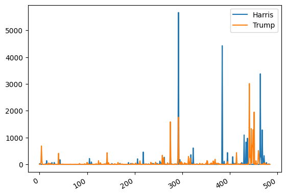

```python
fig, ax = plt.subplots()

line_yes, = ax.plot(cross_category['Harris, Kamala'].to_list(), label='Harris')
line_no, = ax.plot(cross_category['Trump, Donald J.'].to_list(), label='Trump')

fig.autofmt_xdate()

ax.legend(handles = [line_yes, line_no])
plt.show()
```

Conduct a chi-squared test to see if Harris and Trump have similar spending patterns state by state, as in do they both focus on the same states?

```python
harristrump_spending_df = spending_df[(spending_df['cand_nm'] == 'Harris, Kamala') | (spending_df['cand_nm'] == 'Trump, Donald J.')]
cross_state = pd.crosstab(harristrump_spending_df['recipient_st'], harristrump_spending_df['cand_nm'])
scipy.stats.chi2_contingency(cross_state).pvalue
```

```
0.0
```

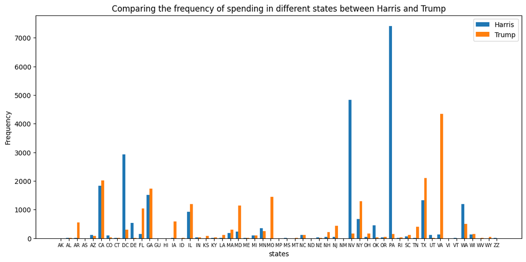

```python
fig, ax = plt.subplots(figsize=(13,6))

states = list(cross_state.index)
bar_width = 0.35


observed_bars = ax.bar(np.arange(len(states)), cross_state['Harris, Kamala'], bar_width, label='Harris')
expected_bars = ax.bar(np.arange(len(states)) + bar_width, cross_state['Trump, Donald J.'], bar_width, label='Trump')

# Add labels and annotations
ax.set_xticks(np.arange(len(states)) + bar_width / 2, states, size='x-small')
ax.set_xlabel('states')
ax.set_ylabel('Frequency')
ax.set_title('Comparing the frequency of spending in different states between Harris and Trump')
ax.set
ax.legend()
plt.show()
```

# TEST 2: Correlation

```python
# https://www.fec.gov/data/candidates/president/presidential-map/
# spending - allcandidates
types = {
    "cmte_id" : str,
    "cand_id" : str,
    "recipient_nm" : str,
    "disb_amt" : float,
    "disb_dt" : str,
    "recipient_city" : str,
    "recipient_st" : str,
    "recipient_zip" : str,
    "disb_desc" : str,
    "memo_cd" : str,
    "memo_text" : str,
    "form_tp" : str,
    "file_num" : str,
    "tran_id" : str,
    "election_tp" : str
}

spending_df = pd.read_csv("spending_data_2024.csv", index_col=False, dtype=types)
spending_df["disb_dt"] = pd.to_datetime(spending_df["disb_dt"], format='%d-%b-%y')
# spending_df
```

```python
cand_info = pd.read_csv("weball24.txt", delimiter='|')
# cand_info
```

```python
poll_data = pd.read_csv("presidential_general_averages.csv")
poll_data["date"] = pd.to_datetime(poll_data["date"])
# poll_data
```

Correlation Between Trump's and Harris's Total Spending and National Polling Average

```python
# Add column to poll_data with state abbreviations
states_abbr = spending_df.recipient_st.unique()
# states_abbr
```

```python
state_abbrvs = pd.read_csv("states.csv", index_col = 0)
# state_abbrvs.head()
```

```python
states = poll_data.state.unique()
# [s for s in states if s not in state_abbrvs["Abbreviation"]]
```

```python
abbrvs = list()

for s in poll_data["state"]:
    if (s == 'ME-1') | (s == 'ME-2') | (s == 'Maine Cd 2'):
        abbrvs.append("ME")
    elif s == "NE-2":
        abbrvs.append("NE")
    elif s == "Nebraska Cd 2":
        abbrvs.append("NE")
    elif s == "National":
        abbrvs.append("National")
    else:
        abbrvs.append(state_abbrvs["Abbreviation"][s])

poll_data["state_abbrv"] = abbrvs
# poll_data
```

```python
harris_spending_23_24 = spending_df[spending_df["cand_nm"] == "Harris, Kamala"]
hs_spending_per_day = harris_spending_23_24.groupby("disb_dt")["disb_amt"].sum()
# hs_spending_per_day
```

```python
harris_spending_23_24 = spending_df[spending_df["cand_nm"] == "Harris, Kamala"]
hs_spending_per_day_per_state = harris_spending_23_24.groupby(["recipient_st","disb_dt"])["disb_amt"].sum()
hs_spending_per_day_per_state_df = pd.DataFrame(index = hs_spending_per_day_per_state.index.get_level_values("disb_dt").unique(), columns = hs_spending_per_day_per_state.index.get_level_values("recipient_st").unique())

for st in hs_spending_per_day_per_state_df.columns:
    hs_spending_per_day_per_state_df[st] = hs_spending_per_day_per_state[st]

hs_spending_per_day_per_state_df =hs_spending_per_day_per_state_df.fillna(0)
# hs_spending_per_day_per_state_df
```

```python
trump_spending_23_24 = spending_df[(spending_df["cand_nm"] == "Trump, Donald J.")]
tp_spending_per_day = trump_spending_23_24.groupby("disb_dt")["disb_amt"].sum()
# tp_spending_per_day
```

```python
trump_spending_23_24 = spending_df[spending_df["cand_nm"] == "Trump, Donald J."]
tp_spending_per_day_per_state = trump_spending_23_24.groupby(["recipient_st","disb_dt"])["disb_amt"].sum()
tp_spending_per_day_per_state_df = pd.DataFrame(index = tp_spending_per_day_per_state.index.get_level_values("disb_dt").unique(), columns = tp_spending_per_day_per_state.index.get_level_values("recipient_st").unique())

for st in tp_spending_per_day_per_state_df.columns:
    tp_spending_per_day_per_state_df[st] = tp_spending_per_day_per_state[st]
tp_spending_per_day_per_state_df = tp_spending_per_day_per_state_df.fillna(0)
# tp_spending_per_day_per_state_df.head()
```

```python
harris_nat_polls = poll_data[(poll_data["candidate"] == "Harris") & (poll_data["state"] == "National")]
# harris_nat_polls
```

```python
trump_nat_polls = poll_data[(poll_data["candidate"] == "Trump") & (poll_data["state"] == "National")]
# trump_nat_polls.head()
```

```python
trump_spending_to_polls = trump_nat_polls[["date", "pct_estimate"]].set_index("date")
trump_spending_to_polls = trump_spending_to_polls[trump_spending_to_polls.index.isin(tp_spending_per_day.index)]
trump_spending_to_polls["total_spending"] = tp_spending_per_day
# trump_spending_to_polls
```

```python
harris_spending_to_polls = harris_nat_polls[["date", "pct_estimate"]].set_index("date")
harris_spending_to_polls = harris_spending_to_polls[harris_spending_to_polls.index.isin(hs_spending_per_day.index)]
harris_spending_to_polls["total_spending"] = hs_spending_per_day
# harris_spending_to_polls.head()
```

```python
harris_corr_mtx = harris_spending_to_polls.corr(method="spearman")
harris_corr_mtx
```

|  | pct_estimate | total_spending |
| --- | --- | --- |
| pct_estimate | 1.000000 | 0.126721 |
| total_spending | 0.126721 | 1.000000 |

```python
trump_corr_mtx = trump_spending_to_polls.corr(method="spearman")
trump_corr_mtx
```

|  | pct_estimate | total_spending |
| --- | --- | --- |
| pct_estimate | 1.000000 | -0.038858 |
| total_spending | -0.038858 | 1.000000 |

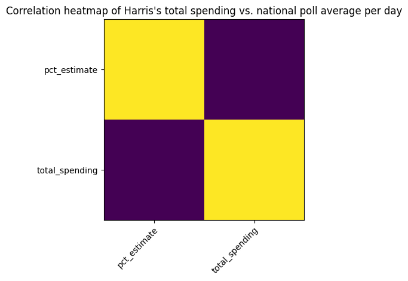

```python
fig, ax = plt.subplots()
im = ax.imshow(harris_corr_mtx)

# Show all ticks and label them with the respective list entries
ax.set_xticks(range(2), labels=harris_corr_mtx.index)
ax.set_yticks(range(2), labels=harris_corr_mtx.columns)

# Rotate the tick labels and set their alignment.
plt.setp(ax.get_xticklabels(), rotation=45, ha="right",
         rotation_mode="anchor")

ax.set_title("Correlation heatmap of Harris's total spending vs. national poll average per day")
fig.tight_layout()
plt.show()
```

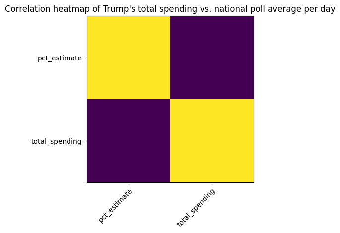

```python
fig, ax = plt.subplots()
im = ax.imshow(trump_corr_mtx)

# Show all ticks and label them with the respective list entries
ax.set_xticks(range(2), labels=trump_corr_mtx.index)
ax.set_yticks(range(2), labels=trump_corr_mtx.columns)

# Rotate the tick labels and set their alignment.
plt.setp(ax.get_xticklabels(), rotation=45, ha="right",
         rotation_mode="anchor")

ax.set_title("Correlation heatmap of Trump's total spending vs. national poll average per day")
fig.tight_layout()
plt.show()
```

```python
harris_corr_mtx = hs_spending_per_day_per_state_df.corr(method="spearman")
```

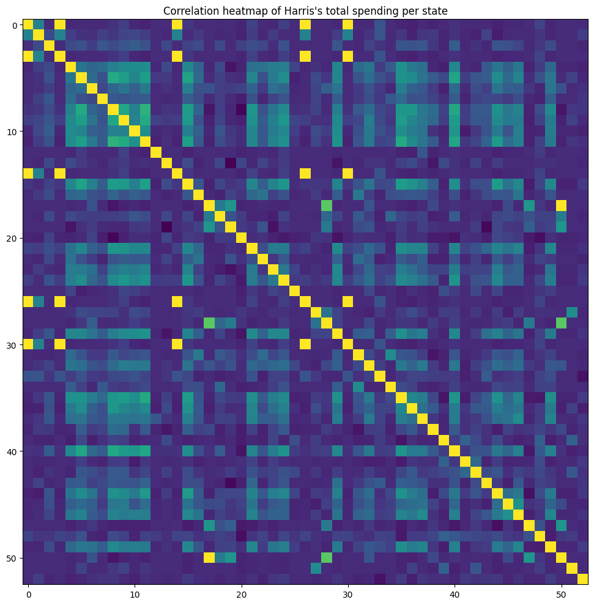

```python
fig, ax = plt.subplots(figsize = (10, 10))
im = ax.imshow(harris_corr_mtx)

plt.figure(figsize=(1000,1000))

ax.set_title("Correlation heatmap of Harris's total spending per state")
fig.tight_layout()
plt.show()
```

```python
trump_corr_mtx = tp_spending_per_day_per_state_df.corr(method="spearman")
```

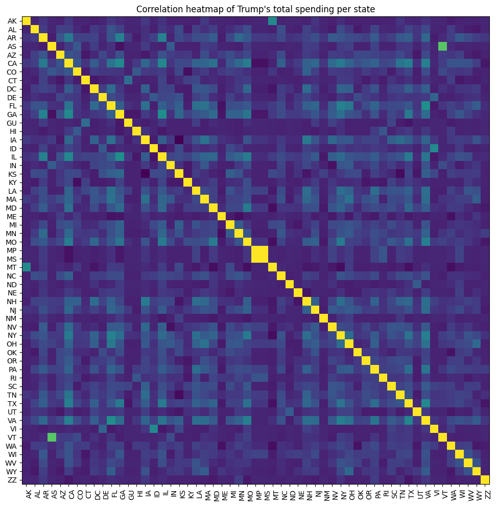

```python
fig, ax = plt.subplots(figsize=(10, 10))
im = ax.imshow(trump_corr_mtx)

# Show all ticks and label them with the respective list entries
ax.set_xticks(range(55), labels=trump_corr_mtx.index, fontsize=10)
ax.set_yticks(range(55), labels=trump_corr_mtx.columns, fontsize=10)

#Rotate the tick labels and set their alignment.
plt.setp(ax.get_xticklabels(), rotation=90, ha="right",
         rotation_mode="anchor")

ax.set_title("Correlation heatmap of Trump's total spending per state")
fig.tight_layout()
plt.show()
```

Analysis:

When discovering the correlation between estimated poll and total spending, Spearman correlation is applied due to the unknown nature of the relationship. Harris' stats present a weak positive correlation between her spending and her estimated poll. This implies that the increased spending have little impact on her polling performance. Trump's stats present a weak negative correlation between his spending and his estimated poll. This implies that the increased spending wouldn't likely to impact on his polling performance or have slight negative impact. Harris have benefits little from the spending, while trump didn't. This may impies that Trump have more solid brand recognition than Harris. Volters volt Trump dispite his spending. While Harris may need to spend more to gain public recognition. The spending of both candidates presents low impact on the result. This may implies that officially count spending is not the primary factor that influence the poll. External influences like support from public celebrities (e.g. Elon Musk/Taylor Swift) or donation to Pro-Trump, Pro-Harris Committee impact more. Another possible reason is that some states are Pro-Democrates or Pro-Republics by default. Both candidates may spend more at states that oppose with their party and receive relatively weak response.

For the correlation between spending of each states, The presence of more green clusters on Harris’s heatmap compared to Trump’s indicates that Harris's state-level spending patterns are more correlated across multiple states. This implies that Harris have more consistent spending strategy across states. Her spending may be more universal across multiple states. On the opposite, Trump's spending may be more targeted, focusing on specific states independently with different priorities. Trump may allocate resources opportunistically, depending on shifting poll numbers or last-minute campaign needs, leading to less consistency in spending patterns.

# TEST 3: 1 Tailed Wilcoxon Test

```python
polling_df = pd.read_csv('presidential_general_averages.csv')
polling_df['date'] = pd.to_datetime(polling_df['date']).dt.date

harris_df = polling_df[(polling_df['candidate'].str.contains('Harris')) & (polling_df['date'] >= datetime.date(2024, 7, 24)) & (polling_df['state'] == 'National')][['date', 'pct_estimate']]

trump_df = polling_df[(polling_df['candidate'].str.contains('Trump')) & (polling_df['date'] >= datetime.date(2024, 7, 24)) & (polling_df['state'] == 'National')][['date', 'pct_estimate']]

wilcoxon(harris_df['pct_estimate'], trump_df['pct_estimate'], alternative='greater')
```

```
WilcoxonResult(statistic=5565.0, pvalue=2.917717369616875e-19)
```

```python
polling_df = pd.read_csv('presidential_general_averages.csv')
polling_df['date'] = pd.to_datetime(polling_df['date']).dt.date
```

Analysis: The 'date' column is stored as a string and must be converted to a datetime value before use. The pct_trend_adjusted and pct_estimate columns are mutually exclusive, all rows which have a number in the pct_trend_adjusted column have NaN in the pct_estimate column, and vice versa. All of the most recent polls have pct_estimate and not pct_trend_adjusted. Some of the entries contain the full names of the candidates, e.g. 'Joseph R. Biden', while others only contain the last name 'Biden'. The polls include both state specific poll numbers and national averages.

In the code below, a one-tailed Wilcoxon Signed-Rank test is performed where the pairs consist of the national poll averages for Harris and Trump on the same date. This test was chosen because the polling numbers for Harris and Trump are related, especially on the same date, and polling averages cannot safely be assumed to be normal over time.

$H_0 = \mu_{\text{Harris}} <= \mu_{\text{Trump}}$  
$H_A = \mu_{\text{Harris}} > \mu_{\text{Trump}}$

$\alpha = 0.05$

Since p-value < $\alpha$, we reject the null hypothesis. Given the incredibly small p-value, it is incredibly unlikely that Harris's national polling numbers are less than or equal to Trump's. Harris's poll numbers are greater than Trump's in a statistically significant manner.

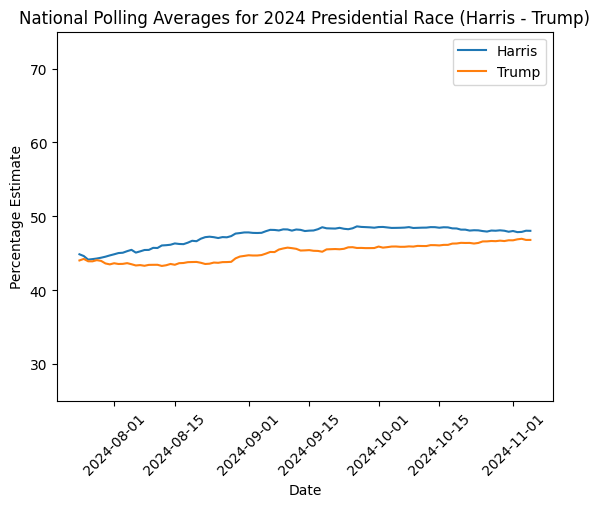

```python
sns.lineplot(data=harris_df, x='date', y='pct_estimate', label='Harris')
sns.lineplot(data=trump_df, x='date', y='pct_estimate', label='Trump')

plt.title('National Polling Averages for 2024 Presidential Race (Harris - Trump)')
plt.xlabel('Date')
plt.ylabel('Percentage Estimate')

plt.xticks(rotation=45)
plt.ylim(bottom=25, top=75)
plt.show()
```

# **SECTION 5: Primary Analysis**

Need a constant that will help convert the predicted states into actual electoral vote counts.

```python
electoral_votes = {
    "Alabama": 9,
    "Alaska": 3,
    "Arizona": 11,
    "Arkansas": 6,
    "California": 54,
    "Colorado": 10,
    "Connecticut": 7,
    "Delaware": 3,
    "District of Columbia": 3,
    "Florida": 30,
    "Georgia": 16,
    "Hawaii": 4,
    "Idaho": 4,
    "Illinois": 19,
    "Indiana": 11,
    "Iowa": 6,
    "Kansas": 6,
    "Kentucky": 8,
    "Louisiana": 8,
    "Maine": 2,
    "ME-1": 1,
    "ME-2": 1,
    "Maryland": 10,
    "Massachusetts": 11,
    "Michigan": 15,
    "Minnesota": 10,
    "Mississippi": 6,
    "Missouri": 10,
    "Montana": 4,
    "Nebraska": 2,
    "NE-1": 1,
    "NE-2": 1,
    "NE-3": 1,
    "Nevada": 6,
    "New Hampshire": 4,
    "New Jersey": 14,
    "New Mexico": 5,
    "New York": 28,
    "North Carolina": 16,
    "North Dakota": 3,
    "Ohio": 17,
    "Oklahoma": 7,
    "Oregon": 8,
    "Pennsylvania": 19,
    "Rhode Island": 4,
    "South Carolina": 9,
    "South Dakota": 3,
    "Tennessee": 11,
    "Texas": 40,
    "Utah": 6,
    "Vermont": 3,
    "Virginia": 13,
    "Washington": 12,
    "West Virginia": 4,
    "Wisconsin": 10,
    "Wyoming": 3
}
```

Due to this complex relationship between polling and spending data and election results, we decided to use a Multi-layer Perceptron. Being a neural network, it is better suited to handle more complex relationships.

Furthermore, because we want to avoid label encoding in order to avoid introducing unintended ordinal relationships for the states, we will use One-Hot Encoding. Since there are 56 state/districts, this encoding will greatly increase the dimensionality of our dataset. Neural networks are also better suited to handling higher dimensional data.

To learn more about the inner workings of Multi-layer Perceptrons, go to: https://www.datacamp.com/tutorial/multilayer-perceptrons-in-machine-learning

1. We will need to convert some categorical variables into encodings and normalize the numeric columns.

```python
# Specify the column to apply OneHotEncoder
categorical_columns = ['state']

# Specify the columns for StandardScaler (assuming X_train is a DataFrame)
numerical_columns = [col for col in X_train.columns if col not in categorical_columns]

# Set up a preprocessor to help convert categorial columns into One Hot Encodings, and normalize the other values
preprocessor = ColumnTransformer(
    transformers=[
        ('onehot', OneHotEncoder(handle_unknown='ignore'), categorical_columns),
        ('scaler', StandardScaler(), numerical_columns)
    ]
)
```

2. Now, we will need to create a MLPClassifier

Note: Because our dataset is relatively small, we will use the 'lbfgs' solver for the Multi-layer Perceptron Classifier as it tends to perform better on smaller datasets.

```python
classifier = MLPClassifier(max_iter=500, solver='lbfgs', random_state=0)
```

3. We will add each classifier to a pipline with the preprocessor.

```python
pipeline = Pipeline(steps=[
    ('preprocessor', preprocessor),
    ('model', classifier)
])
```

4. Now run the pipeline on the data

```python
pipeline.fit(X_train, y_train)

y_pred = pipeline.predict(X_test)

final_results = X_test.copy()
final_results['actual'] = y_test
final_results['predict'] = y_pred
final_results[~(final_results['actual'] == final_results['predict'])]

final_results['electoral_votes'] = final_results['state'].map(lambda e: electoral_votes[e])

# Get the total electoral votes for each party
final_results[['predict', 'electoral_votes']].groupby('predict').sum()
```

| predict | electoral_votes |
| --- | --- |
| DEMOCRAT | 225 |
| REPUBLICAN | 310 |

Note: Because DC was lacking any polling for the 2024 cycle, it was not predicted, so the predicted electoral vote totals do not add to the correct 538.

Compare the predicted results to the actual results below:

Actual election results:

DEMOCRAT: 226

REPUBLICAN: 312

Real results excluding DC:

DEMOCRAT: 223

REPUBLICAN: 312

The electoral vote totals are close, but we still don't know if the model is actually accurate. In order to check this, get the classification report.

For more information on what these scores mean: https://developers.google.com/machine-learning/crash-course/classification/accuracy-precision-recall

```python
print(classification_report(y_test, y_pred))
```

```
              precision    recall  f1-score   support

    DEMOCRAT       0.95      0.95      0.95        21
  REPUBLICAN       0.97      0.97      0.97        34

    accuracy                           0.96        55
   macro avg       0.96      0.96      0.96        55
weighted avg       0.96      0.96      0.96        55
```

We can see that the model scored very well on all metrics.

Now we will also perform K-fold Cross Validation with 5 folds to validate the accuracy of the model. As we can see, the accuracy is pretty high.

StratifiedKFold Documentation: https://scikit-learn.org/dev/modules/generated/sklearn.model_selection.StratifiedKFold.html

More about K-Fold Cross Validation: https://www.datacamp.com/tutorial/k-fold-cross-validation

```python
k_folds = 5
skf = StratifiedKFold(n_splits=k_folds, shuffle=True, random_state=0)

cv_scores = cross_val_score(pipeline, X_train, y_train, cv=skf, scoring='accuracy')

mean_accuracy = cv_scores.mean()
std_accuracy = cv_scores.std()

print(f"Model: MLP Classifier\tCross-validation accuracy: {mean_accuracy} (+/- {std_accuracy})")
```

```
Model: MLP Classifier	Cross-validation accuracy: 0.9008859357696567 (+/- 0.023311119177733607)
```

# **SECTION 6: Visualization**

First, we make a copy of the results dataframe that can be indexed by state name.

```python
results_trimmed = final_results.copy().set_index('state')
results_trimmed["actual_scalar"] = [-1 if party == "DEMOCRAT" else 1 for party in results_trimmed["actual"]]
results_trimmed["predict_scalar"] = [-1 if party == "DEMOCRAT" else 1 for party in results_trimmed["predict"]]
```

## Geographic Visualization of Spending and Polling Data

Let's visualize the features we used in the machine learning prediction to see if they share any common patterns with the electoral results. We will use a workflow based on demo from BaseMap's GitHub (https://github.com/matplotlib/basemap/blob/master/examples/fillstates.py)

```python
def plot_geo_features(colname, vmin, vmax, title, label):
    fig, ax = plt.subplots()

    # Lambert Conformal map of lower 48 states.
    m = Basemap(llcrnrlon=-119,llcrnrlat=20,urcrnrlon=-64,urcrnrlat=49,
                projection='lcc',lat_1=33,lat_2=45,lon_0=-95)

    # Mercator projection, for Alaska and Hawaii
    m_ = Basemap(llcrnrlon=-190,llcrnrlat=20,urcrnrlon=-143,urcrnrlat=46,
                projection='merc',lat_ts=20)  # do not change these numbers

    #%% ---------   draw state boundaries  ----------------------------------------
    ## data from U.S Census Bureau
    ## http://www.census.gov/geo/www/cob/st2000.html
    shp_info = m.readshapefile('st99_d00','states',drawbounds=True,
                               linewidth=0.45,color='gray')
    shp_info_ = m_.readshapefile('st99_d00','states',drawbounds=False)

    #%% -------- choose a color for each state based on electoral results. -------

    colors={}
    statenames=[]
    cmap = plt.cm.viridis_r
    #vmin = 0
    #vmax = results_trimmed[colname].max()
    norm = Normalize(vmin=vmin, vmax=vmax)
    for shapedict in m.states_info:
        #print(shapedict)
        statename = shapedict['NAME']
        # skip DC and Puerto Rico.
        if statename not in ['District of Columbia','Puerto Rico']:
            data_pt = results_trimmed[colname][statename]

            # calling colormap with value between 0 and 1 returns
            # rgba value.
            colors[statename] = cmap((data_pt-vmin)/(vmax-vmin))[:3]
        statenames.append(statename)

    #%% ---------  cycle through state names, color each one.  --------------------

    for nshape,seg in enumerate(m.states):
        # skip DC and Puerto Rico.
        if statenames[nshape] not in ['Puerto Rico', 'District of Columbia']:
            color = rgb2hex(colors[statenames[nshape]])
            poly = Polygon(seg,facecolor=color,edgecolor=color)
            ax.add_patch(poly)

    AREA_1 = 0.005  # exclude small Hawaiian islands that are smaller than AREA_1
    AREA_2 = AREA_1 * 30.0  # exclude Alaskan islands that are smaller than AREA_2
    AK_SCALE = 0.19  # scale down Alaska to show as a map inset
    HI_OFFSET_X = -1900000  # X coordinate offset amount to move Hawaii "beneath" Texas
    HI_OFFSET_Y = 250000    # similar to above: Y offset for Hawaii
    AK_OFFSET_X = -250000   # X offset for Alaska (These four values are obtained
    AK_OFFSET_Y = -750000   # via manual trial and error, thus changing them is not recommended.)

    for nshape, shapedict in enumerate(m_.states_info):  # plot Alaska and Hawaii as map insets
        if shapedict['NAME'] in ['Alaska', 'Hawaii']:
            seg = m_.states[int(shapedict['SHAPENUM'] - 1)]
            if shapedict['NAME'] == 'Hawaii' and float(shapedict['AREA']) > AREA_1:
                seg = [(x + HI_OFFSET_X, y + HI_OFFSET_Y) for x, y in seg]
                color = rgb2hex(colors[statenames[nshape]])
            elif shapedict['NAME'] == 'Alaska' and float(shapedict['AREA']) > AREA_2:
                seg = [(x*AK_SCALE + AK_OFFSET_X, y*AK_SCALE + AK_OFFSET_Y)\
                       for x, y in seg]
                color = rgb2hex(colors[statenames[nshape]])
            poly = Polygon(seg, facecolor=color, edgecolor='gray', linewidth=.45)
            ax.add_patch(poly)

    ax.set_title(title)

    #%% ---------  Plot bounding boxes for Alaska and Hawaii insets  --------------
    light_gray = [0.8]*3  # define light gray color RGB
    x1,y1 = m_([-190,-183,-180,-180,-175,-171,-171],[29,29,26,26,26,22,20])
    x2,y2 = m_([-180,-180,-177],[26,23,20])  # these numbers are fine-tuned manually
    m_.plot(x1,y1,color=light_gray,linewidth=0.8)  # do not change them drastically
    m_.plot(x2,y2,color=light_gray,linewidth=0.8)

    #%% ---------   Show color bar  ---------------------------------------
    ax_c = fig.add_axes([0.9, 0.1, 0.03, 0.8])
    cb = ColorbarBase(ax_c,cmap=cmap,norm=norm,orientation='vertical',
                  label=label)

    plt.show()
```

### Plot Spending Distribution

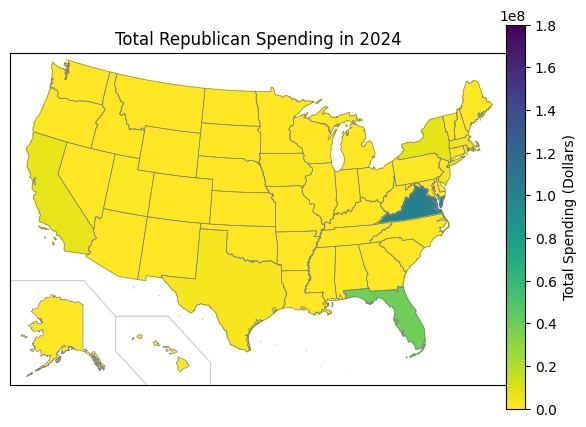

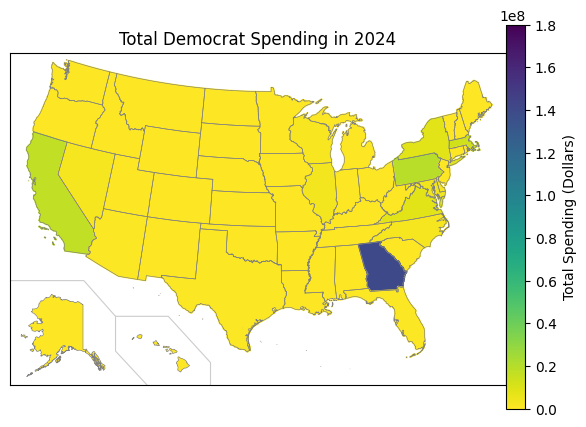

```python
plot_geo_features("spending_total_republican", 0, 1.8*10**8, 'Total Republican Spending in 2024', 'Total Spending (Dollars)')
plot_geo_features("spending_total_democrat",0, 1.8*10**8, 'Total Democrat Spending in 2024', 'Total Spending (Dollars)')
```

The distribution of spending for both parties were similar - the bulk of campaign spending for both parties was concentrated in highly populated states. Similar to what we see in the data exploration section, the Democrats spent the most money in California, Pennsylvania, and Georgia, while the Republicans spent the most money in Florida and Virginia.

### Plot Average Polling Results

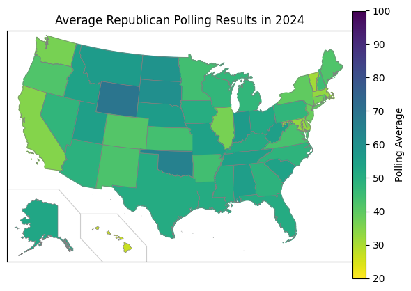

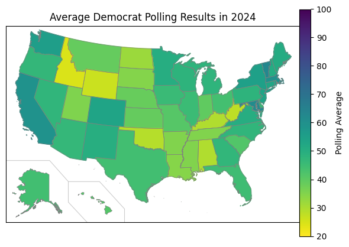

```python
plot_geo_features("polling_avg_republican", 20, 100, 'Average Republican Polling Results in 2024', 'Polling Average')
plot_geo_features("polling_avg_democrat", 20, 100, 'Average Democrat Polling Results in 2024', 'Polling Average')
```

As expected, both parties won the states that they polled well in. Democrats polled the best in California and much of the east coast, while Republicans polled well in the Midwest and Southern states. Polling data seems to be a much better predictor of electoral results than spending data - just by eyeballing the polling results versus the electoral results, the patterns seem to match up.

## Geographic Visual Comparison of Predicted vs. Actual Electoral Results

Here we will use BaseMap to visualize the predicted versus actual distibution of electoral votes to see how well our prediction did.

### Find Incorrectly Classified States

```python
diff = final_results[final_results["actual"] != final_results["predict"]]
diff
```

|  | state | polling_avg_republican | polling_avg_democrat | month_change_republican | month_change_democrat | spending_total_republican | spending_total_democrat | actual | predict | electoral_votes |
| --- | --- | --- | --- | --- | --- | --- | --- | --- | --- | --- |
| 10 | Hawaii | 26.600000 | 41.500000 | 0.00000 | 0.0000 | 10000.00 | 2500.00 | DEMOCRAT | REPUBLICAN | 4 |
| 32 | Nevada | 47.597982 | 47.735036 | -0.97476 | 0.0476 | 463308.84 | 2302961.48 | REPUBLICAN | DEMOCRAT | 6 |

### Plot Electoral Vote Distribution

```python
# Based on demo from BaseMap's GitHub: https://github.com/matplotlib/basemap/blob/master/examples/fillstates.py
def plot_votes(colname, title):
    fig, ax = plt.subplots()

    # Lambert Conformal map of lower 48 states.
    m = Basemap(llcrnrlon=-119,llcrnrlat=20,urcrnrlon=-64,urcrnrlat=49,
                projection='lcc',lat_1=33,lat_2=45,lon_0=-95)

    # Mercator projection, for Alaska and Hawaii
    m_ = Basemap(llcrnrlon=-190,llcrnrlat=20,urcrnrlon=-143,urcrnrlat=46,
                projection='merc',lat_ts=20)  # do not change these numbers

    #%% ---------   draw state boundaries  ----------------------------------------
    ## data from U.S Census Bureau
    ## http://www.census.gov/geo/www/cob/st2000.html
    shp_info = m.readshapefile('st99_d00','states',drawbounds=True,
                               linewidth=0.45,color='gray')
    shp_info_ = m_.readshapefile('st99_d00','states',drawbounds=False)

    #%% -------- choose a color for each state based on electoral results. -------

    colors={}
    statenames=[]
    cmap = plt.cm.seismic
    vmin = -54
    vmax = 54
    norm = Normalize(vmin=vmin, vmax=vmax)
    for shapedict in m.states_info:
        #print(shapedict)
        statename = shapedict['NAME']
        # skip DC and Puerto Rico.
        if statename not in ['District of Columbia','Puerto Rico']:
            votes = electoral_votes[statename] * results_trimmed[colname][statename]

            # calling colormap with value between 0 and 1 returns
            # rgba value.
            colors[statename] = cmap((votes-vmin)/(vmax-vmin))[:3]
        statenames.append(statename)

    #%% ---------  cycle through state names, color each one.  --------------------

    for nshape,seg in enumerate(m.states):
        # skip DC and Puerto Rico.
        if statenames[nshape] not in ['Puerto Rico', 'District of Columbia']:
            color = rgb2hex(colors[statenames[nshape]])
            poly = Polygon(seg,facecolor=color,edgecolor=color)
            ax.add_patch(poly)

    AREA_1 = 0.005  # exclude small Hawaiian islands that are smaller than AREA_1
    AREA_2 = AREA_1 * 30.0  # exclude Alaskan islands that are smaller than AREA_2
    AK_SCALE = 0.19  # scale down Alaska to show as a map inset
    HI_OFFSET_X = -1900000  # X coordinate offset amount to move Hawaii "beneath" Texas
    HI_OFFSET_Y = 250000    # similar to above: Y offset for Hawaii
    AK_OFFSET_X = -250000   # X offset for Alaska (These four values are obtained
    AK_OFFSET_Y = -750000   # via manual trial and error, thus changing them is not recommended.)

    for nshape, shapedict in enumerate(m_.states_info):  # plot Alaska and Hawaii as map insets
        if shapedict['NAME'] in ['Alaska', 'Hawaii']:
            seg = m_.states[int(shapedict['SHAPENUM'] - 1)]
            if shapedict['NAME'] == 'Hawaii' and float(shapedict['AREA']) > AREA_1:
                seg = [(x + HI_OFFSET_X, y + HI_OFFSET_Y) for x, y in seg]
                color = rgb2hex(colors[statenames[nshape]])
            elif shapedict['NAME'] == 'Alaska' and float(shapedict['AREA']) > AREA_2:
                seg = [(x*AK_SCALE + AK_OFFSET_X, y*AK_SCALE + AK_OFFSET_Y)\
                       for x, y in seg]
                color = rgb2hex(colors[statenames[nshape]])
            poly = Polygon(seg, facecolor=color, edgecolor='gray', linewidth=.45)
            ax.add_patch(poly)

    ax.set_title(title)

    #%% ---------  Plot bounding boxes for Alaska and Hawaii insets  --------------
    light_gray = [0.8]*3  # define light gray color RGB
    x1,y1 = m_([-190,-183,-180,-180,-175,-171,-171],[29,29,26,26,26,22,20])
    x2,y2 = m_([-180,-180,-177],[26,23,20])  # these numbers are fine-tuned manually
    m_.plot(x1,y1,color=light_gray,linewidth=0.8)  # do not change them drastically
    m_.plot(x2,y2,color=light_gray,linewidth=0.8)

    #%% ---------   Show color bar  ---------------------------------------
    ax_c = fig.add_axes([0.9, 0.1, 0.03, 0.8])
    cb = ColorbarBase(ax_c,cmap=cmap,norm=norm,orientation='vertical', ticks=[-54, -27, 0, 27, 54])
    cb.ax.set_yticklabels(['54 D', '27 D', '0', '27 R', '54 R'])  # vertically oriented colorbar

    plt.show()
```

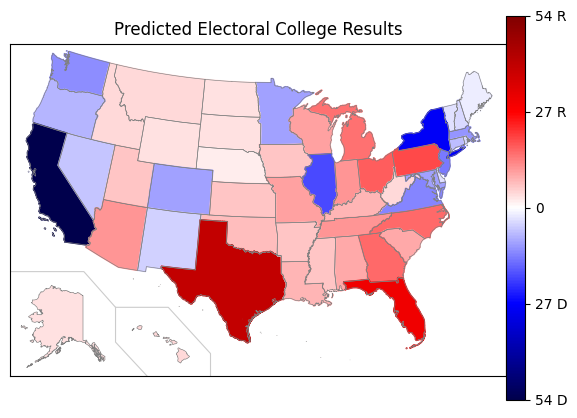

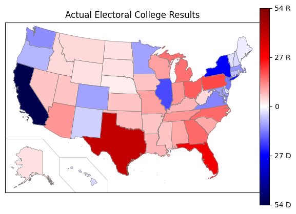

```python
plot_votes("predict_scalar", 'Predicted Electoral College Results')

plot_votes("actual_scalar", 'Actual Electoral College Results')
```

Time to play a game of "Spot the Difference". The predicted and actual results are very similar, indicating that the features we chose are good predictors of which party a state will vote for.

## PCA and Explained Variance of Features

To visualize which features were most important for predicting election results, we conduct a simple PCA on the training data

Scikit learn PCA Documentation: https://scikit-learn.org/dev/modules/generated/sklearn.decomposition.PCA.html

More about PCA: https://www.turing.com/kb/guide-to-principal-component-analysis

First, run PCA and visualize the explained variance of each principle component

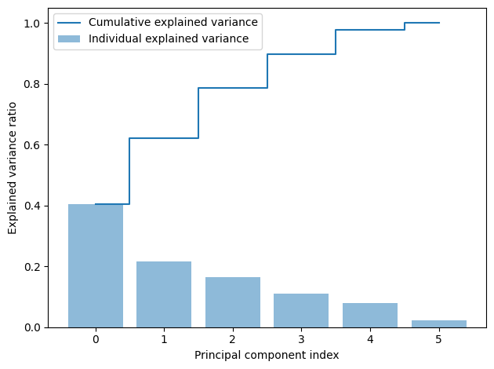

```python
from sklearn.decomposition import PCA

sc = StandardScaler()
sc.fit(X_train.set_index('state'))
X_train_std = sc.transform(X_train.set_index('state'))
X_test_std = sc.transform(X_test.set_index('state'))

# Instantiate PCA
pca = PCA()
# Determine transformed features
X_train_pca = pca.fit_transform(X_train_std)

# Determine explained variance using explained_variance_ration_ attribute
exp_var_pca = pca.explained_variance_ratio_

# Cumulative sum of eigenvalues; This will be used to create step plot
# for visualizing the variance explained by each principal component.
cum_sum_eigenvalues = np.cumsum(exp_var_pca)

# Create the visualization plot
plt.bar(range(0,len(exp_var_pca)), exp_var_pca, alpha=0.5, align='center', label='Individual explained variance')
plt.step(range(0,len(cum_sum_eigenvalues)), cum_sum_eigenvalues, where='mid',label='Cumulative explained variance')
plt.ylabel('Explained variance ratio')
plt.xlabel('Principal component index')
plt.legend(loc='best')
plt.tight_layout()
plt.show()
```

We can then visualize how much each feature contributes to each PC by finding the correlation between the principle components and the original features.

```python
mtx = np.dot(X_train_std.T, X_train_pca)
```

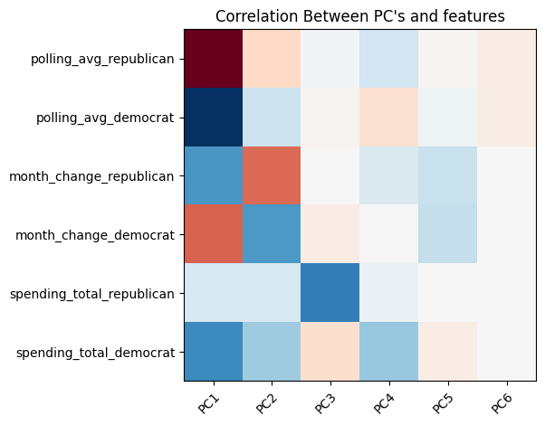

```python
fig, ax = plt.subplots()
im = ax.imshow(mtx, cmap='RdBu')

# Show all ticks and label them with the respective list entries
ax.set_xticks(range(6), labels=['PC1', 'PC2','PC3','PC4','PC5','PC6'])
ax.set_yticks(range(6), labels=X_train.columns[1:])

# Rotate the tick labels and set their alignment.
plt.setp(ax.get_xticklabels(), rotation=45, ha="right",
         rotation_mode="anchor")

ax.set_title("Correlation Between PC's and features")
fig.tight_layout()
plt.show()
```

We can see that the most 'important' features (ie. the features contributing the most variance) are polling average and one-month change in polling.

# **SECTION 7: Insights and Conclusions**

## Future Approaches

- Testing this model on other elections, such as senate elections or even then 2028 presidential election.
- Investigate what factors affect polling, such as campaign spending in specific areas, quality of branding, endorsements by famous figures, or even internet traffic.
- Investigate which swing states' polling results are sensitive to which kinds of campaign activity.